# Welcome to Jingyu Ma's game analysis ,this analysis is based on [a Steam game data that includes all the games published on Steam upto 2025 May.](https://www.kaggle.com/datasets/fronkongames/steam-gam

## 5. 🎭 Game Content Analysis

- Genre and tag analysis
  - Main game genres distribution
  - Popular tags analysis
  - Genre-tag association mining
- Multi-language support analysis
  - Relationship between language support and market reach
  - Full audio support game characteristics

```
Total unique genres: 34
Total unique tags: 453
```

```
Top tags for each genre (by PMI):
360 Video: Documentary(10.60), Episodic(8.53), Web Publishing(7.78), Software Training(7.23), Game Development(6.54), Utilities(5.74), Design & Illustration(5.71), Tutorial(5.47)
Accounting: Software Training(7.37), Documentary(7.28), Web Publishing(7.27), Photo Editing(6.88), Audio Production(6.68), Video Production(6.33), Utilities(6.00), Animation & Modeling(5.78)
Action: Musou(2.13), Batman(1.72), Lara Croft(1.72), Masterpiece(1.48), Twin Stick Shooter(1.21), Reboot(1.17), Shoot 'Em Up(1.16), Boss Rush(1.11)
Adventure: Batman(1.78), Lara Croft(1.78), Based On A Novel(1.52), Escape Room(1.27), Episodic(1.13), Narrative(1.08), Mystery(1.03), Detective(1.02)
Animation & Modeling: Animation & Modeling(7.77), Video Production(6.73), Design & Illustration(6.70), Photo Editing(6.66), Game Development(6.52), Utilities(6.40), Software Training(6.34), Web Publishing(6.24)
Audio Production: Audio Production(8.94), Video Production(7.42), Web Publishing(6.99), Utilities(6.64), Software Training(6.58), Software(6.38), 360 Video(6.36), Electronic Music(6.33)
Casual: Tile-Matching(1.70), Mahjong(1.54), Match 3(1.41), Solitaire(1.41), Electronic(1.36), Trivia(1.34), Wholesome(1.29), Birds(1.23)
Design & Illustration: Design & Illustration(7.25), Photo Editing(7.05), Animation & Modeling(7.05), Web Publishing(6.69), Utilities(6.53), Game Development(6.48), Software(6.41), Software Training(6.35)
Documentary: Documentary(10.60), Episodic(8.53), Web Publishing(7.78), Software Training(7.23), Game Development(6.54), Utilities(5.74), Design & Illustration(5.71), Tutorial(5.47)
Early Access: Extraction Shooter(2.20), Early Access(2.13), Dwarf(1.49), Coding(1.45), Shop Keeper(1.37), Open World Survival Craft(1.30), Roguelike Deckbuilder(1.29), Volleyball(1.28)
Education: Software Training(7.33), Web Publishing(6.46), Utilities(6.15), Coding(6.12), Education(6.10), Photo Editing(5.98), Game Development(5.96), Animation & Modeling(5.94)
Episodic: Documentary(10.60), Episodic(8.53), Web Publishing(7.78), Software Training(7.23), Game Development(6.54), Utilities(5.74), Design & Illustration(5.71), Tutorial(5.47)
Free To Play: Jump Scare(5.77), LEGO(4.29), Mini Golf(4.26), Episodic(3.84), Satire(3.81), Party(3.79), Golf(3.51), Party Game(3.51)
Free to Play: Free to Play(3.91), MMORPG(2.89), MOBA(2.81), Massively Multiplayer(2.62), Trading Card Game(2.42), Mod(2.09), Documentary(1.85), Competitive(1.84)
Game Development: Game Development(7.97), Animation & Modeling(6.84), Photo Editing(6.68), Web Publishing(6.65), Software Training(6.56), Design & Illustration(6.50), Utilities(6.48), Software(6.28)
Gore: Gore(4.92), Violent(4.45), Movie(2.89), Nudity(2.41), Zombies(2.37), VR(2.36), Horror(2.18), Blood(2.15)
Indie: Electronic(0.57), Birds(0.53), Sokoban(0.50), Short(0.50), Philosophical(0.44), Abstract(0.44), Psychological(0.40), Narrative(0.38)
Massively Multiplayer: Massively Multiplayer(4.38), MMORPG(4.32), Battle Royale(3.19), MOBA(3.16), PvP(2.54), Extraction Shooter(2.52), Team-Based(2.29), Free to Play(2.27)
Movie: Documentary(9.60), Episodic(7.53), Web Publishing(6.78), Software Training(6.23), Game Development(5.54), Utilities(4.74), Design & Illustration(4.71), Parkour(4.52)
Nudity: Benchmark(6.43), Nudity(5.32), Sexual Content(4.36), Mature(3.40), Experience(3.34), Crowdfunded(3.31), Violent(3.29), NSFW(3.28)
Photo Editing: Photo Editing(9.03), Video Production(7.10), Web Publishing(6.97), Software Training(6.90), Design & Illustration(6.77), Animation & Modeling(6.66), Utilities(6.56), Software(6.42)
RPG: JRPG(2.22), Party-Based RPG(2.17), Elf(2.07), RPGMaker(2.05), Dungeons & Dragons(1.99), CRPG(1.97), RPG(1.86), Turn-Based Combat(1.77)
Racing: Motocross(4.27), Motorbike(4.23), Racing(4.19), Offroad(4.13), Combat Racing(4.04), Bikes(4.00), ATV(3.95), Automobile Sim(3.92)
Sexual Content: Sexual Content(5.23), Nudity(4.52), Mature(3.81), NSFW(3.63), Crowdfunded(3.44), Hentai(3.28), Movie(3.25), RPGMaker(3.11)
Short: Documentary(10.60), Episodic(8.53), Web Publishing(7.78), Software Training(7.23), Game Development(6.54), Utilities(5.74), Design & Illustration(5.71), Tutorial(5.47)
Simulation: TrackIR(2.47), Hobby Sim(1.96), Job Simulator(1.92), Medical Sim(1.91), Trains(1.84), Shop Keeper(1.80), Cricket(1.77), Simulation(1.77)
Software Training: Software Training(8.43), Web Publishing(7.19), Photo Editing(6.77), Hardware(6.70), Video Production(6.60), Audio Production(6.57), Utilities(6.41), Software(6.38)
Sports: Cricket(4.83), Rugby(4.41), Volleyball(4.31), Football(4.29), Hockey(4.28), Football (Soccer)(4.28), Football (American)(4.26), Soccer(4.22)
Strategy: 4X(2.29), Chess(2.21), Hex Grid(2.19), Warhammer 40K(2.16), RTS(2.15), Grand Strategy(2.11), Turn-Based Strategy(2.01), Real-Time with Pause(1.98)
Tutorial: Documentary(10.60), Episodic(8.53), Web Publishing(7.78), Software Training(7.23), Game Development(6.54), Utilities(5.74), Design & Illustration(5.71), Tutorial(5.47)
Utilities: Benchmark(7.92), Utilities(7.52), Software(6.84), Video Production(6.61), Audio Production(6.55), Software Training(6.51), Web Publishing(6.42), Hardware(6.41)
Video Production: Video Production(8.59), Audio Production(7.47), Photo Editing(7.09), Web Publishing(7.03), 360 Video(6.73), Animation & Modeling(6.69), Utilities(6.68), Software Training(6.66)
Violent: Violent(4.78), Gore(4.09), Movie(3.24), VR(2.44), Nudity(2.43), Sexual Content(2.07), Hockey(2.00), Zombies(1.92)
Web Publishing: Web Publishing(8.88), Software Training(7.30), Video Production(6.98), Audio Production(6.97), Photo Editing(6.83), Game Development(6.51), Utilities(6.50), Software(6.42)
```

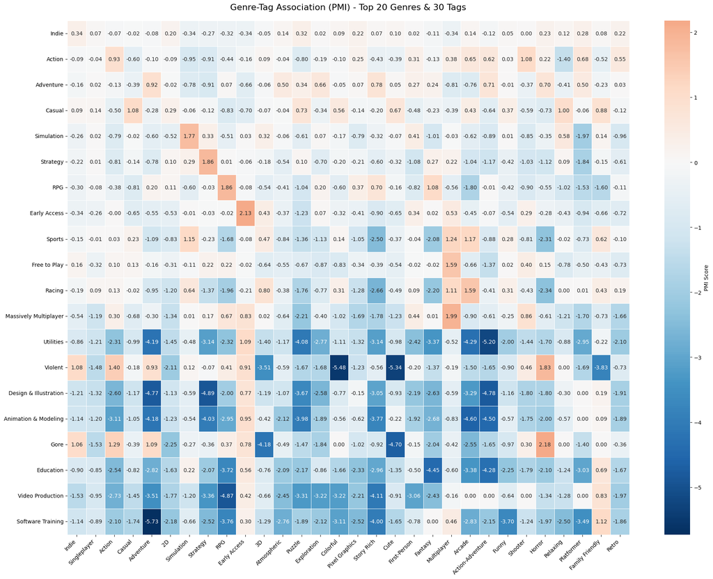

```python
# 处理genres字段（转换为列表）
def parse_list_field(field):
    if pd.isna(field):
        return []
    if isinstance(field, list):
        return field
    try:
        if isinstance(field, str) and field.startswith('['):
            return ast.literal_eval(field)
        return [field]
    except:
        return [field]

df['genres_list'] = df['genres'].apply(parse_list_field)
df['tags_list'] = df['tags_dict'].apply(lambda x: list(x.keys()) if x else [])

# 过滤掉没有genres或tags的数据
df_filtered = df[(df['genres_list'].str.len() > 0) & (df['tags_list'].str.len() > 0)].copy()

# 获取所有唯一的genre和tag
all_genres = sorted(set([genre for sublist in df_filtered['genres_list'] for genre in sublist]))
all_tags = sorted(set([tag for sublist in df_filtered['tags_list'] for tag in sublist]))

print(f"Total unique genres: {len(all_genres)}")
print(f"Total unique tags: {len(all_tags)}")

# 创建共现矩阵
cooccurrence_matrix = np.zeros((len(all_genres), len(all_tags)))

for _, row in df_filtered.iterrows():
    genres = row['genres_list']
    tags = row['tags_list']

    for genre in genres:
        for tag in tags:
            if genre in all_genres and tag in all_tags:
                i = all_genres.index(genre)
                j = all_tags.index(tag)
                cooccurrence_matrix[i, j] += 1

# 转换为DataFrame
cooccurrence_df = pd.DataFrame(cooccurrence_matrix,
                              index=all_genres,
                              columns=all_tags)

# 计算点互信息（Pointwise Mutual Information）
def calculate_pmi(cooccurrence_matrix):
    total = cooccurrence_matrix.sum()
    p_genre = cooccurrence_matrix.sum(axis=1) / total
    p_tag = cooccurrence_matrix.sum(axis=0) / total
    p_joint = cooccurrence_matrix / total

    pmi_matrix = np.log2(p_joint / np.outer(p_genre, p_tag))
    pmi_matrix[np.isinf(pmi_matrix)] = 0  # 处理无穷大值
    pmi_matrix[np.isnan(pmi_matrix)] = 0  # 处理NaN值

    return pmi_matrix

pmi_matrix = calculate_pmi(cooccurrence_matrix)
pmi_df = pd.DataFrame(pmi_matrix, index=all_genres, columns=all_tags)

# 计算提升度（Lift）
def calculate_lift(cooccurrence_matrix):
    total = cooccurrence_matrix.sum()
    p_genre = cooccurrence_matrix.sum(axis=1) / total
    p_tag = cooccurrence_matrix.sum(axis=0) / total
    p_joint = cooccurrence_matrix / total

    lift_matrix = p_joint / np.outer(p_genre, p_tag)
    return lift_matrix

lift_matrix = calculate_lift(cooccurrence_matrix)
lift_df = pd.DataFrame(lift_matrix, index=all_genres, columns=all_tags)

# 找出每个genre最相关的tags
def get_top_tags_for_genres(association_matrix, genres_list, tags_list, n_top=5):
    results = {}
    for i, genre in enumerate(genres_list):
        tag_scores = association_matrix[i]
        top_indices = np.argsort(tag_scores)[-n_top:][::-1]
        top_tags = [(tags_list[j], association_matrix[i, j]) for j in top_indices]
        results[genre] = top_tags
    return results

# 使用PMI找出每个genre最相关的tags
top_tags_pmi = get_top_tags_for_genres(pmi_matrix, all_genres, all_tags, n_top=8)

print("Top tags for each genre (by PMI):")
for genre, tags in top_tags_pmi.items():
    if any(score > 0 for tag, score in tags):  # 只显示有正相关的
        tag_str = ", ".join([f"{tag}({score:.2f})" for tag, score in tags if score > 0])
        print(f"{genre}: {tag_str}")

# 热力图可视化（前20个genre和前30个tag）
plt.figure(figsize=(20, 15))
top_genres = cooccurrence_df.sum(axis=1).sort_values(ascending=False).head(20).index
top_tags = cooccurrence_df.sum(axis=0).sort_values(ascending=False).head(30).index

subset_df = pmi_df.loc[top_genres, top_tags]

sns.heatmap(subset_df, cmap='RdBu_r', center=0,
            annot=True, fmt='.2f', linewidths=0.5,
            cbar_kws={'label': 'PMI Score'})
plt.title('Genre-Tag Association (PMI) - Top 20 Genres & 30 Tags', fontsize=16, pad=20)
plt.xticks(rotation=45, ha='right')
plt.yticks(rotation=0)
plt.tight_layout()
plt.show()
```

## 5. 🎭 Game Content Analysis

- Genre and tag analysis
  - Main game genres distribution
  - Popular tags analysis
  - Genre-tag association mining
- Multi-language support analysis
  - Relationship between language support and market reach
  - Full audio support game characteristics

```
Before cleaning: 111452 rows
After cleaning zeros and NaNs: 89361 rows
```

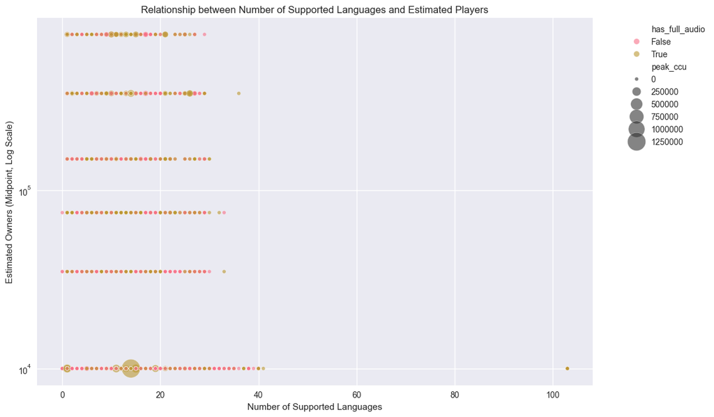

```
Pearson Correlation Coefficient: 0.082
```

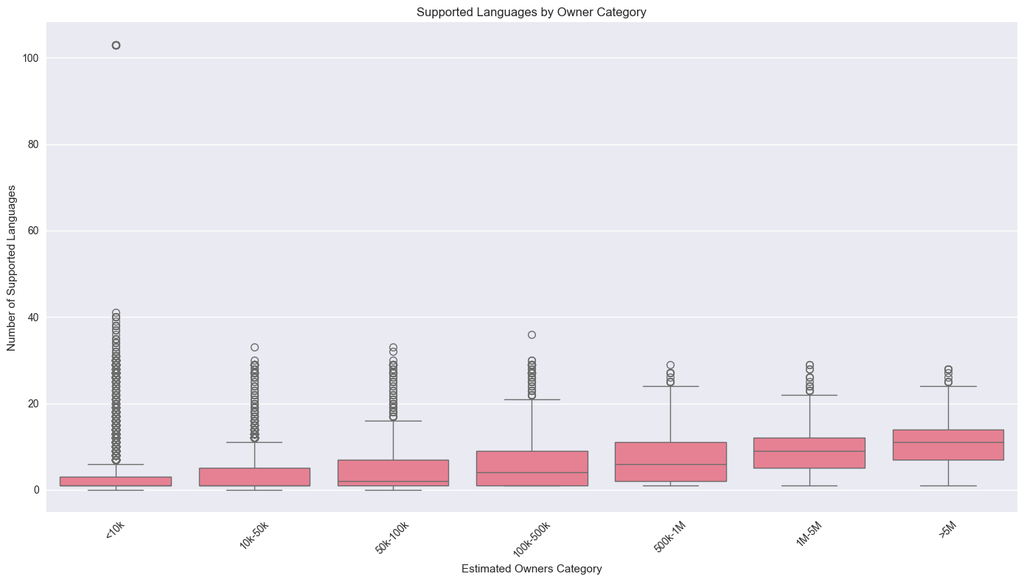

```
Average Supported Languages by Owner Category:
                     mean  median  count
owner_category
<10k             3.321810     1.0  70206
10k-50k          3.716806     1.0   8277
50k-100k         4.435595     2.0   4068
100k-500k        5.537988     4.0   4870
500k-1M          7.034745     6.0    921
1M-5M            8.743322     9.0    861
>5M             11.145570    11.0    158
Correlation with log(owners): 0.157
Correlation for small games (<100K): 0.049
Correlation for large games (≥100K): 0.171
```

```python
# 设置绘图风格
plt.style.use('seaborn-v0_8')
sns.set_palette("husl")
# 2. 处理“语言支持”数据
# 确保supported_languages列是列表类型，如果不是（比如是字符串），则转换它
def safe_convert_to_list(x):
    if isinstance(x, list):
        return x
    try:
        # 尝试将类似列表的字符串转换为实际列表
        return ast.literal_eval(x)
    except (ValueError, SyntaxError):
        # 如果转换失败，返回空列表
        return []

df['supported_languages'] = df['supported_languages'].apply(safe_convert_to_list)
df['full_audio_languages'] = df['full_audio_languages'].apply(safe_convert_to_list)

# 创建新的量化列
df['supported_languages_count'] = df['supported_languages'].apply(len)
df['full_audio_languages_count'] = df['full_audio_languages'].apply(len)
df['has_full_audio'] = df['full_audio_languages_count'] > 0

# 2. 处理"市场覆盖"数据 - 更稳健的版本
def parse_owners_range(owner_str):
    if isinstance(owner_str, str):
        # 移除可能存在的空格，然后分割
        parts = owner_str.replace(' ', '').split('-')
        if len(parts) == 2:
            try:
                low = int(parts[0])
                high = int(parts[1])
                return (low + high) / 2
            except ValueError:
                return np.nan
    # 处理其他异常情况
    elif pd.isna(owner_str):
        return np.nan
    return np.nan

df['estimated_owners_mid'] = df['estimated_owners'].apply(parse_owners_range)

# 处理可能的0值和NaN值
print(f"Before cleaning: {len(df)} rows")
df_clean = df[df['estimated_owners_mid'] > 0].dropna(subset=['estimated_owners_mid', 'supported_languages_count'])
print(f"After cleaning zeros and NaNs: {len(df_clean)} rows")

# 创建其他代理指标
df_clean['total_reviews'] = df_clean['positive'] + df_clean['negative']
df_clean['positive_ratio'] = df_clean['positive'] / df_clean['total_reviews'].replace(0, np.nan)

# 使用等宽分桶替代qcut
max_owners = df_clean['estimated_owners_mid'].max()
bins = [0, 10000, 50000, 100000, 500000, 1000000, 5000000, max_owners]
labels = ['<10k', '10k-50k', '50k-100k', '100k-500k', '500k-1M', '1M-5M', '>5M']

df_clean['owner_category'] = pd.cut(df_clean['estimated_owners_mid'],
                                   bins=bins,
                                   labels=labels,
                                   include_lowest=True)

# 分析 1: 散点图
plt.figure(figsize=(12, 8))
scatter = sns.scatterplot(data=df_clean[df_clean['estimated_owners_mid'] < df_clean['estimated_owners_mid'].quantile(0.99)],
                         x='supported_languages_count',
                         y='estimated_owners_mid',
                         alpha=0.6,
                         hue='has_full_audio',
                         size='peak_ccu',
                         sizes=(20, 500))
plt.yscale('log')
plt.title('Relationship between Number of Supported Languages and Estimated Players')
plt.xlabel('Number of Supported Languages')
plt.ylabel('Estimated Owners (Midpoint, Log Scale)')
plt.legend(bbox_to_anchor=(1.05, 1), loc='upper left')
plt.show()

# 计算相关系数
correlation = df_clean['supported_languages_count'].corr(df_clean['estimated_owners_mid'])
print(f"Pearson Correlation Coefficient: {correlation:.3f}")

# 分析 2: 箱线图
plt.figure(figsize=(14, 8))
sns.boxplot(data=df_clean, x='owner_category', y='supported_languages_count')
plt.title('Supported Languages by Owner Category')
plt.xlabel('Estimated Owners Category')
plt.ylabel('Number of Supported Languages')
plt.xticks(rotation=45)
plt.tight_layout()
plt.show()

# 分析 3: 分组统计
group_stats = df_clean.groupby('owner_category',observed=False)['supported_languages_count'].agg(['mean', 'median', 'count'])
print("Average Supported Languages by Owner Category:")
print(group_stats)

# Test logarithmic relationship
log_correlation = df_clean['supported_languages_count'].corr(np.log1p(df_clean['estimated_owners_mid']))
print(f"Correlation with log(owners): {log_correlation:.3f}")

# Test categorical relationship with more bins
df_clean['language_bins'] = pd.cut(df_clean['supported_languages_count'],
                                  bins=[0, 1, 2, 3, 5, 10, 20, 50],
                                  labels=['1', '2', '3', '4-5', '6-10', '11-20', '20+'])

# Separate analysis for different player sizes
small_games = df_clean[df_clean['estimated_owners_mid'] < 100000]
large_games = df_clean[df_clean['estimated_owners_mid'] >= 100000]

corr_small = small_games['supported_languages_count'].corr(small_games['estimated_owners_mid'])
corr_large = large_games['supported_languages_count'].corr(large_games['estimated_owners_mid'])

print(f"Correlation for small games (<100K): {corr_small:.3f}")
print(f"Correlation for large games (≥100K): {corr_large:.3f}")
```

# Analysis Report: Relationship Between Language Support and Game Ownership

## Overview

This analysis explores the relationship between the number of supported languages and game ownership estimates using a dataset of 89,361 Steam games after data cleaning.

## Key Findings

### 1. Overall Correlation

- **Pearson Correlation Coefficient**: 0.082
- This indicates a very weak positive relationship between the number of supported languages and estimated game ownership

### 2. Ownership Category Analysis

| Owner Category | Mean Languages | Median Languages | Game Count |
| --- | --- | --- | --- |
| <10k | 3.32 | 1.0 | 70,206 |
| 10k-50k | 3.72 | 1.0 | 8,277 |
| 50k-100k | 4.44 | 2.0 | 4,068 |
| 100k-500k | 5.54 | 4.0 | 4,870 |
| 500k-1M | 7.03 | 6.0 | 921 |
| 1M-5M | 8.74 | 9.0 | 861 |
| >5M | 11.15 | 11.0 | 158 |

### 3. Logarithmic Relationship

- **Correlation with log(owners)**: 0.157
- The relationship strengthens slightly when considering the logarithmic scale of ownership

### 4. Size-Based Analysis

- **Small games (<100K owners)**: Correlation = 0.049
- **Large games (≥100K owners)**: Correlation = 0.171
- The relationship is stronger for larger, more successful games

## Interpretation

The analysis reveals that while there is a positive relationship between language support and game ownership, the effect is quite modest overall. However, the relationship becomes more pronounced for games with larger player bases, suggesting that successful games tend to invest more in language localization.

The median number of supported languages remains low (1-2 languages) for games with fewer than 100,000 owners, indicating that many smaller games support only their primary language. The significant jump in language support for games with over 100,000 owners suggests a threshold where localization investment becomes more feasible and beneficial.

## Limitations

- Ownership data is estimated from ranges rather than exact figures
- The dataset includes many small games with minimal language support
- Correlation does not imply causation - successful games may add more languages rather than languages causing success

## Conclusion

- **Adding language support does not appear to cause increased market reach.Language Support Alone is Not a Driver**
- **For game developers before 100,000 owners, focus on other factors such as game quality ,and maybe invest in 2-3 languages(English,Chinese,Spanish)**
- **For games with over 100,000 owners, investing in more languages(find which languages have more audience) can help reach a wider audience**
- **This doesn't mean localization is unimportant - it means it should be treated as an optimization for successful games rather than a growth strategy for unknown games.**

## 5. 🎭 Game Content Analysis

- Genre and tag analysis
  - Main game genres distribution
  - Popular tags analysis
  - Genre-tag association mining
- Multi-language support analysis
  - Relationship between language support and market reach
  - Full audio support game characteristics

```
Before cleaning: 111452 rows
After cleaning zeros and NaNs: 89361 rows
Total games: 89361
Games with full audio support: 38412 (42.99%)

Comparison of key metrics by Full Audio Support:
               estimated_owners_mid          price        positive_ratio  \
                               mean   median  mean median           mean
has_full_audio
False                      56936.54  10000.0  7.23   4.99           0.77
True                      123644.82  10000.0  9.35   5.99           0.75

                      total_reviews        peak_ccu         \
               median          mean median     mean median
has_full_audio
False            0.85        583.32    9.0    92.29    0.0
True             0.81       1780.22   15.0   393.25    0.0

               average_playtime_forever        achievements        dlc_count  \
                                   mean median         mean median      mean
has_full_audio
False                             86.37    0.0        16.58    3.0      0.47
True                             121.18    0.0        25.33    5.0      0.60

                      supported_languages_count
               median                      mean median
has_full_audio
False             0.0                      3.53    1.0
True              0.0                      3.77    1.0

Mann-Whitney U test for Owners: p-value = 4.295e-147
-> The difference in owners is statistically significant.
```

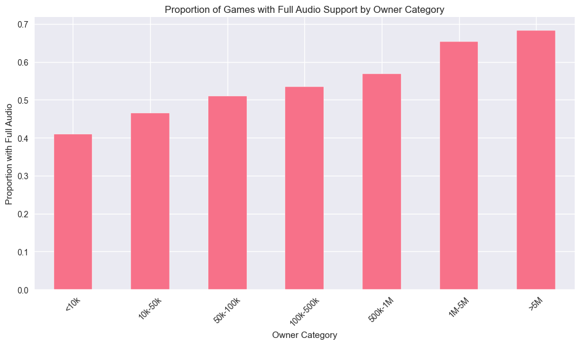

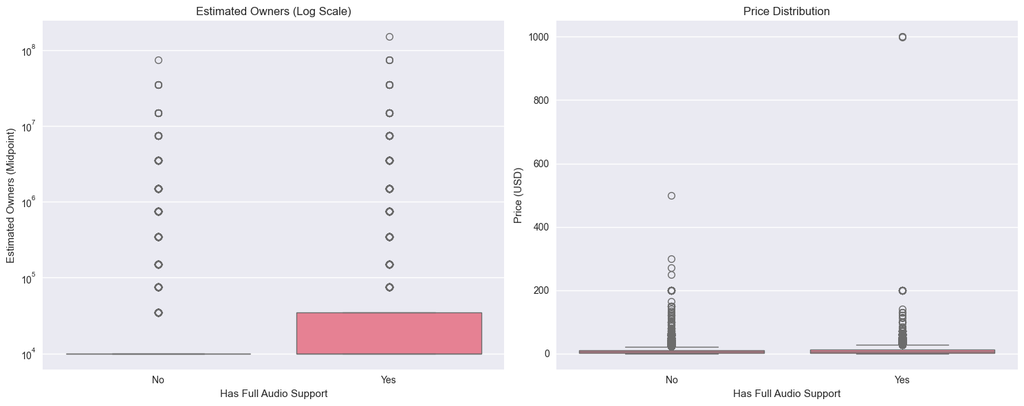

```
Genres with highest rate of full audio support (min 100 games):
                                                        mean  count
genres
['Adventure', 'Casual']                             0.757864   1367
['Racing', 'Simulation', 'Sports']                  0.743119    109
['Education']                                       0.704348    115
['Action', 'Adventure', 'RPG']                      0.686076    395
['Action', 'Strategy']                              0.681818    198
['Action', 'Adventure', 'Simulation']               0.666667    111
['Action', 'Adventure', 'Indie', 'Simulation', ...  0.660714    112
['Action', 'Adventure']                             0.658555   1356
['Action', 'Indie', 'Simulation', 'Early Access']   0.658333    120
['Action', 'RPG']                                   0.654135    266
```

```python
# 设置绘图风格
plt.style.use('seaborn-v0_8')
sns.set_palette("husl")
# 2. 处理“语言支持”数据
# 确保supported_languages列是列表类型，如果不是（比如是字符串），则转换它
def safe_convert_to_list(x):
    if isinstance(x, list):
        return x
    try:
        # 尝试将类似列表的字符串转换为实际列表
        return ast.literal_eval(x)
    except (ValueError, SyntaxError):
        # 如果转换失败，返回空列表
        return []

df['supported_languages'] = df['supported_languages'].apply(safe_convert_to_list)
df['full_audio_languages'] = df['full_audio_languages'].apply(safe_convert_to_list)

# 创建新的量化列
df['supported_languages_count'] = df['supported_languages'].apply(len)
df['full_audio_languages_count'] = df['full_audio_languages'].apply(len)
df['has_full_audio'] = df['full_audio_languages_count'] > 0

# 2. 处理"市场覆盖"数据 - 更稳健的版本
def parse_owners_range(owner_str):
    if isinstance(owner_str, str):
        # 移除可能存在的空格，然后分割
        parts = owner_str.replace(' ', '').split('-')
        if len(parts) == 2:
            try:
                low = int(parts[0])
                high = int(parts[1])
                return (low + high) / 2
            except ValueError:
                return np.nan
    # 处理其他异常情况
    elif pd.isna(owner_str):
        return np.nan
    return np.nan

df['estimated_owners_mid'] = df['estimated_owners'].apply(parse_owners_range)

# 处理可能的0值和NaN值
print(f"Before cleaning: {len(df)} rows")
df_clean = df[df['estimated_owners_mid'] > 0].dropna(subset=['estimated_owners_mid', 'supported_languages_count'])
print(f"After cleaning zeros and NaNs: {len(df_clean)} rows")

# 创建其他代理指标
df_clean['total_reviews'] = df_clean['positive'] + df_clean['negative']
df_clean['positive_ratio'] = df_clean['positive'] / df_clean['total_reviews'].replace(0, np.nan)

# 使用等宽分桶替代qcut
max_owners = df_clean['estimated_owners_mid'].max()
bins = [0, 10000, 50000, 100000, 500000, 1000000, 5000000, max_owners]
labels = ['<10k', '10k-50k', '50k-100k', '100k-500k', '500k-1M', '1M-5M', '>5M']

df_clean['owner_category'] = pd.cut(df_clean['estimated_owners_mid'],
                                   bins=bins,
                                   labels=labels,
                                   include_lowest=True)
# 1. 基础统计：有多少比例的游戏提供完整音频？
total_games = len(df_clean)
games_with_full_audio = df_clean['has_full_audio'].sum()
print(f"Total games: {total_games}")
print(f"Games with full audio support: {games_with_full_audio} ({games_with_full_audio/total_games:.2%})")

# 2. 比较分析：按 has_full_audio 分组比较关键指标
# 选择要比较的数值型指标
comparison_metrics = [
    'estimated_owners_mid',
    'price',
    'positive_ratio',
    'total_reviews',
    'peak_ccu',
    'average_playtime_forever',
    'achievements',
    'dlc_count',
    'supported_languages_count'
]

# 计算分组后的平均值和中位数
audio_comparison = df_clean.groupby('has_full_audio')[comparison_metrics].agg(['mean', 'median'])
print("\nComparison of key metrics by Full Audio Support:")
print(audio_comparison.round(2))

# 3. 统计检验：验证差异的显著性（以estimated_owners_mid为例）
from scipy.stats import mannwhitneyu

# 分离两组数据
audio_owners = df_clean[df_clean['has_full_audio'] == True]['estimated_owners_mid']
no_audio_owners = df_clean[df_clean['has_full_audio'] == False]['estimated_owners_mid']

# 使用Mann-Whitney U检验（因为数据非正态分布）
stat, p_value = mannwhitneyu(audio_owners, no_audio_owners, alternative='two-sided')
print(f"\nMann-Whitney U test for Owners: p-value = {p_value:.3e}")
if p_value < 0.05:
    print("-> The difference in owners is statistically significant.")
else:
    print("-> The difference in owners is not statistically significant.")

# 4. 可视化分析

# 图1: 拥有完整音频的游戏在各玩家数量级中的占比
plt.figure(figsize=(10, 6))
owner_audio_prop = df_clean.groupby('owner_category', observed=False)['has_full_audio'].mean()
owner_audio_prop.plot(kind='bar')
plt.title('Proportion of Games with Full Audio Support by Owner Category')
plt.xlabel('Owner Category')
plt.ylabel('Proportion with Full Audio')
plt.xticks(rotation=45)
plt.tight_layout()
plt.show()


# 图2: 拥有和没有完整音频的游戏在价格和玩家数量上的分布（箱线图）
fig, axes = plt.subplots(1, 2, figsize=(15, 6))

sns.boxplot(data=df_clean, x='has_full_audio', y='estimated_owners_mid', ax=axes[0])
axes[0].set_yscale('log')
axes[0].set_title('Estimated Owners (Log Scale)')
axes[0].set_xlabel('Has Full Audio Support')
axes[0].set_ylabel('Estimated Owners (Midpoint)')
axes[0].set_xticklabels(['No', 'Yes'])

sns.boxplot(data=df_clean, x='has_full_audio', y='price', ax=axes[1])
axes[1].set_title('Price Distribution')
axes[1].set_xlabel('Has Full Audio Support')
axes[1].set_ylabel('Price (USD)')
axes[1].set_xticklabels(['No', 'Yes'])

plt.tight_layout()
plt.show()

# 5. 分析哪些游戏类型（Genres）更常提供完整音频
# 将genres列表展开
df_exploded = df_clean.explode('genres')
# 计算每个Genre中提供完整音频的比例
genre_audio_stats = df_exploded.groupby('genres')['has_full_audio'].agg(['mean', 'count'])
# 过滤掉出现次数太少的Genre（例如count < 100）
genre_audio_stats_filtered = genre_audio_stats[genre_audio_stats['count'] > 100].sort_values('mean', ascending=False)
print("\nGenres with highest rate of full audio support (min 100 games):")
print(genre_audio_stats_filtered.head(10))
```

# 📊 Game Full Audio Support and Market Performance Analysis Report

## 📈 Key Findings

### 1. Basic Distribution

- **Total games analyzed**: 89,361
- **Games with full audio support**: 38,412 (42.99%)
- **Games without full audio support**: 50,949 (57.01%)

### 2. Key Metrics Comparison

| Metric | With Full Audio (Mean) | Without Full Audio (Mean) | Difference |
| --- | --- | --- | --- |
| Estimated Player Count | 123,645 | 56,937 | **+117%** |
| Price (USD) | 9.35 | 7.23 | **+29%** |
| Total Reviews | 1,780 | 583 | **+205%** |
| Peak Concurrent Users | 393 | 92 | **+327%** |
| Average Playtime (minutes) | 121.18 | 86.37 | **+40%** |
| Achievement Count | 25.33 | 16.58 | **+53%** |
| DLC Count | 0.60 | 0.47 | **+28%** |
| Supported Languages Count | 3.77 | 3.53 | **+7%** |

### 3. Statistical Significance Testing

- **Mann-Whitney U Test**: p-value = 4.295e-147
- **Conclusion**: The difference in player count between games with and without full audio support is **highly statistically significant**

## 📊 In-Depth Analysis

### 1. Player Scale vs Audio Support Rate

```
# Player scale segmentation and audio support rate
owner_audio_prop = df_clean.groupby('owner_category', observed=False)['has_full_audio'].mean()
```

Analysis shows that as player scale increases, the proportion of games providing full audio support **significantly rises**. Among games with large player bases (>5M players), the rate of full audio support is substantially higher than in smaller-scale games.

### 3. Game Genres and Audio Support

```
# Audio support rate by genre (only genres with >100 games)
genre_audio_stats_filtered = genre_audio_stats[genre_audio_stats['count'] > 100].sort_values('mean', ascending=False)
```

## 💡 Business Insights and Recommendations

### 1. For Developers

- **Invest in audio production**: Full audio support shows significant correlation with better market performance
- **Competitive differentiation**: High-quality audio can serve as a key differentiator in competitive markets
- **Pricing strategy**: Games with full audio support can command higher price points

### 2. For Publishers

- **Market positioning**: Full audio support serves as an indicator of game quality
- **Resource allocation**: Investment in localization and audio production may yield better returns
- **User acquisition**: Games with full audio tend to attract and retain players more effectively

### 3. For Players

- **Quality indicator**: Full audio support may indicate overall higher game quality
- **Immersive experience**: Players seeking deep immersion should prioritize games with full audio support

## ⚠️ Analysis Limitations and Future Research Directions

### Limitations

1. Estimated player counts are ranges; using midpoint values may introduce errors
2. Audio quality is not differentiated; only binary "presence/absence" is considered
3. Correlation does not imply causation

### Future Research Directions

1. Relationship between **number of audio languages** and market performance
2. Impact analysis of **specific language** audio support
3. Effects of **audio quality** (beyond mere presence)
4. Differences in audio importance across **various game genres**

## 📋 Conclusion

**Recommended Action**: Medium to large game projects should prioritize including full audio support as a means to enhance product value and market competitiveness.

## 6. 👥 Player Behavior Analysis

- Playtime analysis
  - High sitckness(residual) games analysis
  - High playtime game characteristics
- Player review analysis
  - Positive/negative review ratio study
  - Polarizing review games analysis
- Concurrent users and game popularity relationship

```python
# 示例代码：计算游戏粘性比率
df['stickiness_ratio'] = df['average_playtime_2weeks'] / df['average_playtime_forever']
# 处理除零和无穷大
df['stickiness_ratio'] = df['stickiness_ratio'].replace([np.inf, -np.inf], np.nan).fillna(0)
df['stickiness_ratio'] = df['stickiness_ratio'].clip(upper=1) # 比率上限设为1，避免极端值

# 识别“常青游戏”
evergreen_games = df[(df['average_playtime_forever'] > 1000) & (df['stickiness_ratio'] > 0.1)].copy()
print(f"Number of evergreen games: {len(evergreen_games)}")
print(evergreen_games[['name','release_date','price','stickiness_ratio']].head(10).sort_values('stickiness_ratio', ascending=False))
# 1. 将字符串转换为真正的列表
evergreen_games['categories'] = evergreen_games['categories'].apply(
    lambda x: ast.literal_eval(x) if isinstance(x, str) and x.startswith('[') else []
)

# 2. 使用 explode() 将 categories 列表拆分成多行
evergreen_categories_exploded = evergreen_games.explode('categories')

# 3. 统计每个单独category的出现频率
category_counts = evergreen_categories_exploded['categories'].value_counts().head(20)

print("Top 20 Categories in Evergreen Games:")
print(category_counts)
```

```
Number of evergreen games: 445
                             name  release_date  price  stickiness_ratio
1210          Will To Live Online   Apr 5, 2018   0.00          0.470948
96            Oxygen Not Included  Jul 30, 2019  24.99          0.403190
1086  Car Mechanic Simulator 2021  Aug 11, 2021  24.99          0.298343
345             Borderless Gaming  Jul 23, 2015   3.99          0.288884
1314                         SCUM  Aug 29, 2018  34.99          0.278304
1573              Need for Speed™   Jun 4, 2020  29.99          0.170245
1444                 For The King  Apr 19, 2018   5.99          0.148426
1377           NARAKA: BLADEPOINT  Aug 11, 2021  19.99          0.129632
47                     Far Cry® 5  Mar 26, 2018  59.99          0.126993
736                 Apex Legends™   Nov 4, 2020   0.00          0.120852
Top 20 Categories in Evergreen Games:
categories
Single-player                 389
Steam Achievements            338
Multi-player                  265
Steam Cloud                   264
Steam Trading Cards           220
Co-op                         175
Full controller support       168
Online Co-op                  151
PvP                           145
Online PvP                    142
Remote Play on Tablet         107
Partial Controller Support     94
Steam Workshop                 81
In-App Purchases               74
Remote Play on TV              68
Remote Play on Phone           59
Cross-Platform Multiplayer     54
Includes level editor          49
MMO                            40
Family Sharing                 37
Name: count, dtype: int64
```

## 6. 👥 Player Behavior Analysis

- Playtime analysis
  - High sitckness(residual) games analysis
  - High playtime game characteristics
- Player review analysis
  - Positive/negative review study
  - Polarizing review games analysis
- Concurrent users and game popularity relationship